# Smoking Status Prediction

```r
roc_rf=ROCauc(rf3,training)
```

[figure not shown]

```
## [1] "AUC: 1"
```

```r
roc_rf
```

```
## [1] "AUC: 1"
```

#predict and evaluate on test data

```r
modelCM(rf3,test)
```

```
## Confusion Matrix and Statistics
##
##           Reference
## Prediction    0    1
##          0 8972 1318
##          1 1596 4815
##
##                Accuracy : 0.8255
##                  95% CI : (0.8197, 0.8312)
##     No Information Rate : 0.6328
##     P-Value [Acc > NIR] : < 2.2e-16
##
##                   Kappa : 0.6281
##
##  Mcnemar's Test P-Value : 2.876e-07
##
##             Sensitivity : 0.8490
##             Specificity : 0.7851
##          Pos Pred Value : 0.8719
##          Neg Pred Value : 0.7511
##               Precision : 0.8719
##                  Recall : 0.8490
##                      F1 : 0.8603
##              Prevalence : 0.6328
##          Detection Rate : 0.5372
##    Detection Prevalence : 0.6161
##       Balanced Accuracy : 0.8170
##
##        'Positive' Class : 0
##
```

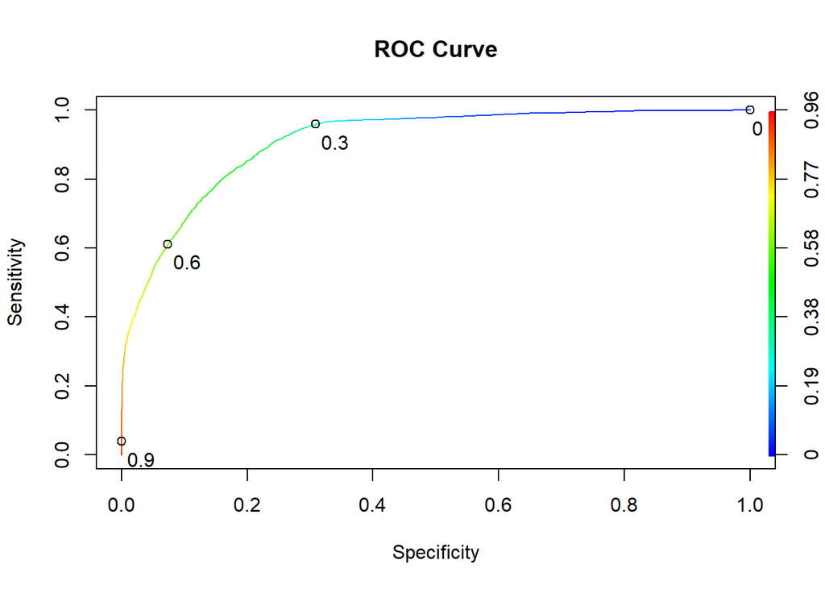

```
## [1] "AUC: 0.911"
```

```r
ROCauc(rf3,test)
```

```r
#random forest best model
pred_ROC= predict(rf3, type='prob', test[,-19])[,2]
pred_rf3= prediction(pred_ROC, test$smoking)
```

#plot to check number of nodes for trees

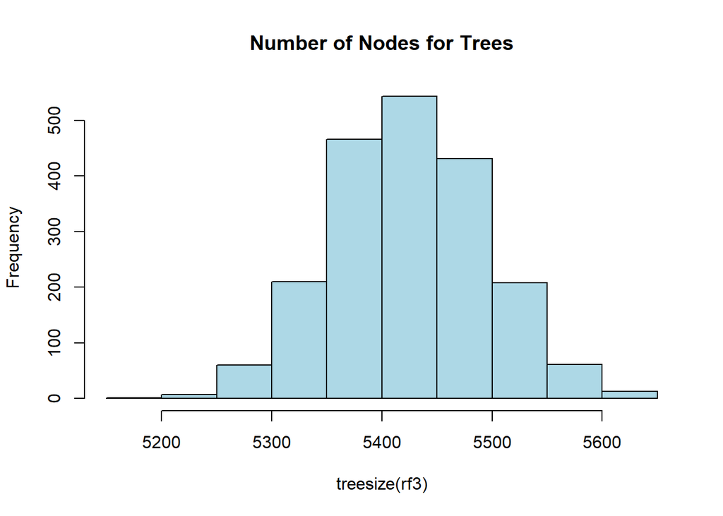

```r
hist(treesize(rf3),
     main= 'Number of Nodes for Trees',
     col= 'lightblue')
```

#check variable importance

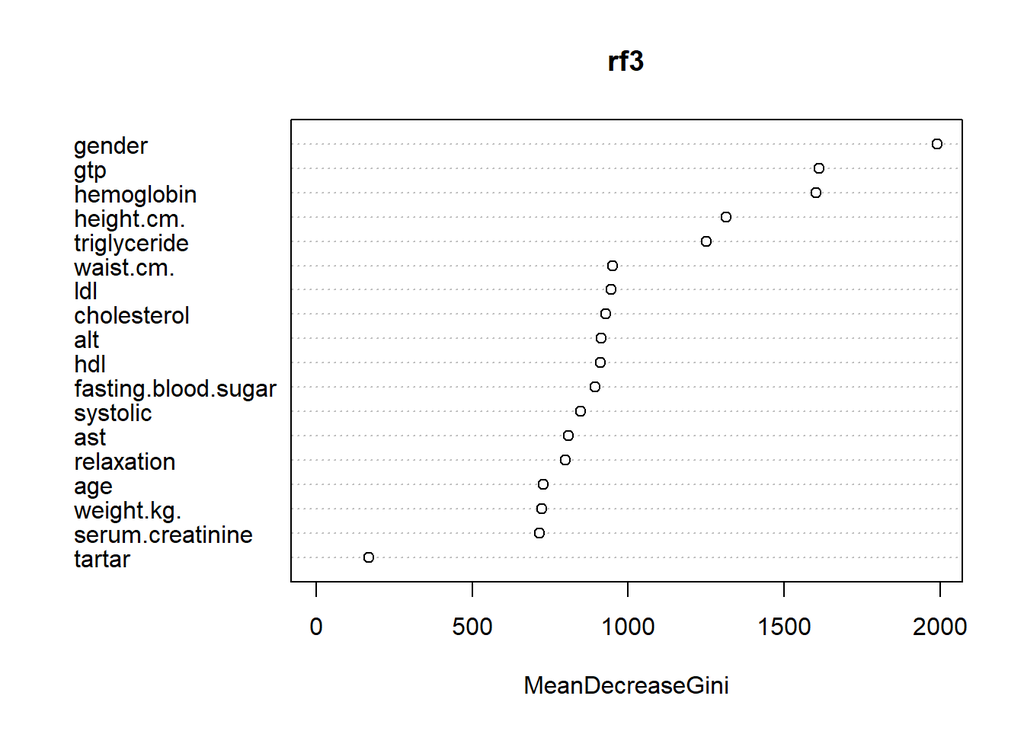

```r
varImpPlot(rf3)
```

```r
importance(rf3)
```

```
##                     MeanDecreaseGini
## gender                     1990.7159
## age                         727.5037
## height.cm.                 1312.8205
## weight.kg.                  722.9738
## waist.cm.                   951.2349
## systolic                    847.4363
## relaxation                  799.8764
## fasting.blood.sugar         895.1126
## cholesterol                 927.0231
## triglyceride               1249.6700
## hdl                         911.1710
## ldl                         946.4196
## hemoglobin                 1602.6227
## serum.creatinine            715.6403
## ast                         809.2825
## alt                         912.4609
## gtp                        1612.4408
## tartar                      168.5013
```

#compare models

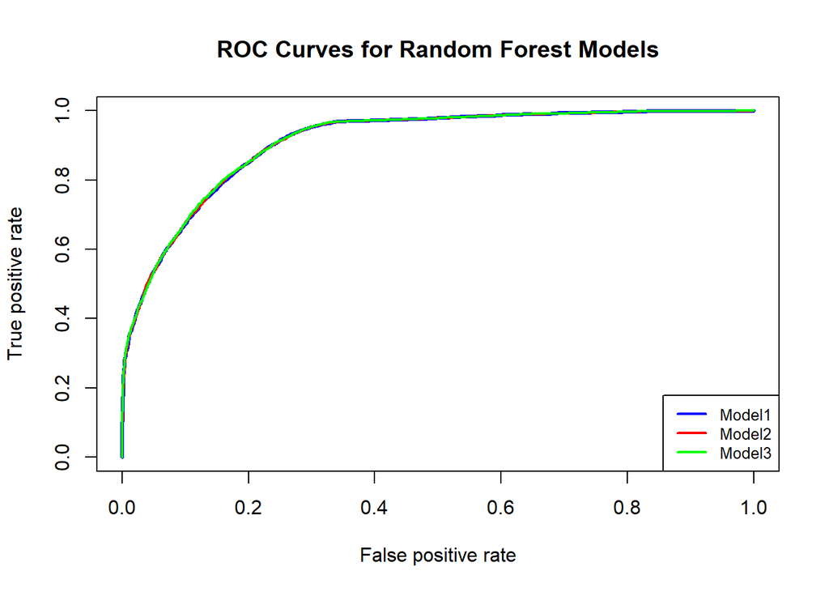

```r
rf1_pred_prob<- predict(rf1, type='prob', test[, -19])[,2]
rf1_pred<- prediction(rf1_pred_prob,test$smoking)
rf1_perf= performance(rf1_pred, 'tpr','fpr')
plot(rf1_perf, col='blue', lwd=3, main='ROC Curves for Random Forest Models')

rf2_pred_prob<- predict(rf2, type='prob',test[, -19])[,2]
rf2_pred= prediction(rf2_pred_prob, test$smoking)
rf2_perf= performance(rf2_pred, 'tpr','fpr')
plot(rf2_perf, col='red', lwd=2, add=TRUE)

rf3_pred_prob= predict(rf3, type='prob',test[, -19])[,2]
rf3_pred= prediction(rf3_pred_prob, test$smoking)
rf3_perf= performance(rf3_pred,'tpr', 'fpr')
plot(rf3_perf, col='green', lwd=2, add=TRUE)

legend('bottomright', legend=c('Model1', 'Model2', 'Model3'), col=c('blue', 'red', 'green'), lwd=2, cex=0.8)
```

********************************************XGBoost************************************************************

XGBoost Extreme Gradient Boosting is one of the boosting ensemble method. it has both linear model and tree learning algorithms. Hence, XGBoost only works with numeric vectors, the categorical variables are converted into numeric vector through one hot encoding.

XGBoost uses a specific data structure (known as DMatrix) to store data

```r
library(xgboost)
set.seed(100)

#define predictor and response variables in training set
train_x<- data.matrix(oh_training[, -21])
train_y<- oh_training[, 21]

#define predictor and response variables in tet set
test_x<- data.matrix(oh_test[, -21])
test_y<- oh_test[,21 ]


#define final training and test sets
xgb_train<- xgb.DMatrix(train_x, label=train_y)
xgb_test<- xgb.DMatrix(data= test_x, label=test_y)
```

#Model 1

#build the model

```r
xgb1<- xgboost( data= train_x, label=train_y,
                     nround=10, max_depth=5, eta=0.5, nthread=2,
                     objective='binary:logistic')
xgb1
```

```
## ##### xgb.Booster
## raw: 30.5 Kb
## call:
##   xgb.train(params = params, data = dtrain, nrounds = nrounds,
##     watchlist = watchlist, verbose = verbose, print_every_n = print_every_n,
##     early_stopping_rounds = early_stopping_rounds, maximize = maximize,
##     save_period = save_period, save_name = save_name, xgb_model = xgb_model,
##     callbacks = callbacks, max_depth = 5, eta = 0.5, nthread = 2,
##     objective = "binary:logistic")
## params (as set within xgb.train):
##   max_depth = "5", eta = "0.5", nthread = "2", objective = "binary:logistic", validate_parameters = "TRUE"
## xgb.attributes:
##   niter
## callbacks:
##   cb.print.evaluation(period = print_every_n)
##   cb.evaluation.log()
## # of features: 20
## niter: 10
## nfeatures : 20
## evaluation_log:
##     iter train_logloss
##        1     0.5568656
##        2     0.5054302
## ---
##        9     0.4403690
##       10     0.4367914
```

#Prediction and evaluation on training set

```r
#predict using training set
xgb1pred_tr <- predict(xgb1, train_x)
#transform them in a 0 1 variable
xgb1pred_tr<- as.numeric(xgb1pred_tr>0.5)
confusionMatrix(factor(xgb1pred_tr),factor(train_y))
```

```
## Confusion Matrix and Statistics
##
##           Reference
## Prediction     0     1
##          0 19691  3653
##          1  4967 10656
##
##                Accuracy : 0.7788
##                  95% CI : (0.7746, 0.7829)
##     No Information Rate : 0.6328
##     P-Value [Acc > NIR] : < 2.2e-16
##
##                   Kappa : 0.533
##
##  Mcnemar's Test P-Value : < 2.2e-16
##
##             Sensitivity : 0.7986
##             Specificity : 0.7447
##          Pos Pred Value : 0.8435
##          Neg Pred Value : 0.6821
##              Prevalence : 0.6328
##          Detection Rate : 0.5053
##    Detection Prevalence : 0.5991
##       Balanced Accuracy : 0.7716
##
##        'Positive' Class : 0
##
```

#ROC plot and AUC

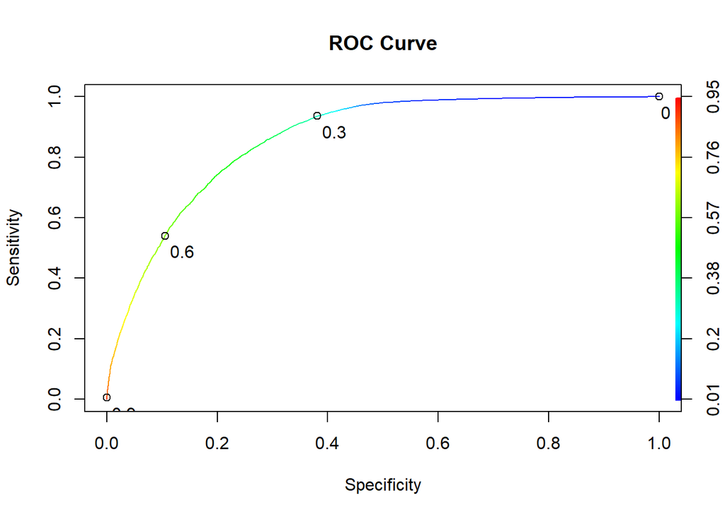

```r
xgb1pred_ROC= predict(xgb1, train_x, type='prob')
xgb1pred= prediction(xgb1pred_ROC, train_y)
perf= performance(xgb1pred,'tpr', 'fpr')
plot(perf, colorize=T,
       main='ROC Curve',
       ylab= 'Sensitivity',
       xlab= 'Specificity',
       print.cutoffs.at=seq(0,1,0.3),
       text.adj= c(-0.2,1.7))
```

```r
auc= as.numeric(performance(xgb1pred, 'auc')@y.values)
auc=round(auc,3)
print(paste('AUC:', auc))
```

```
## [1] "AUC: 0.862"
```

#predict and evaluate on test set

```r
#predict using training set
xgb1pred_ts <- predict(xgb1, test_x)
#transform them in a 0 1 variable
xgb1pred_ts<- as.numeric(xgb1pred_ts>0.5)
confusionMatrix(factor(xgb1pred_ts),factor(test_y))
```

```
## Confusion Matrix and Statistics
##
##           Reference
## Prediction    0    1
##          0 8253 1769
##          1 2315 4364
##
##                Accuracy : 0.7555
##                  95% CI : (0.7489, 0.762)
##     No Information Rate : 0.6328
##     P-Value [Acc > NIR] : < 2.2e-16
##
##                   Kappa : 0.4835
##
##  Mcnemar's Test P-Value : < 2.2e-16
##
##             Sensitivity : 0.7809
##             Specificity : 0.7116
##          Pos Pred Value : 0.8235
##          Neg Pred Value : 0.6534
##              Prevalence : 0.6328
##          Detection Rate : 0.4942
##    Detection Prevalence : 0.6001
##       Balanced Accuracy : 0.7463
##
##        'Positive' Class : 0
##
```

#ROC plot and AUC

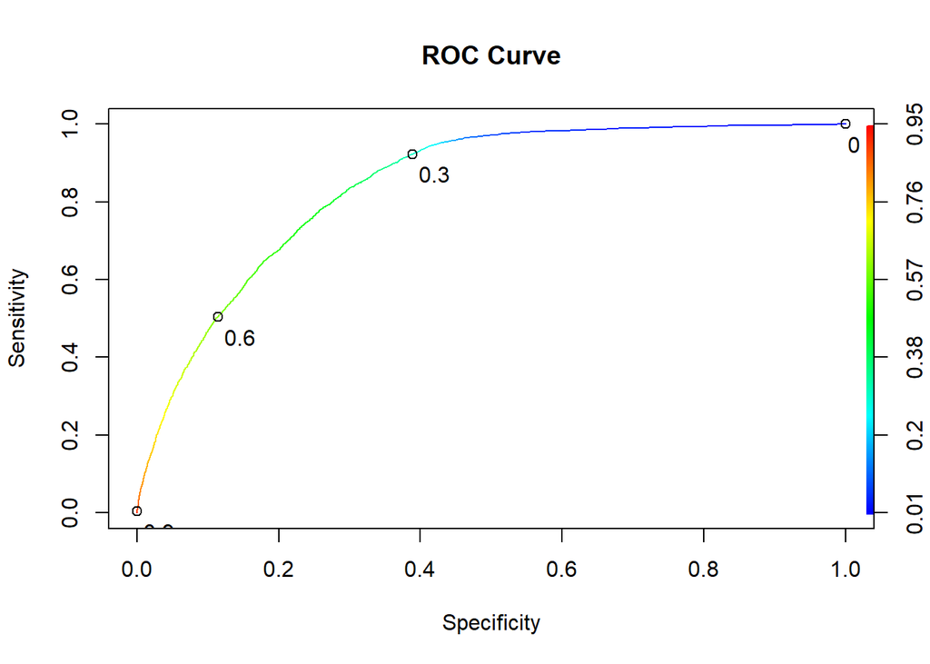

```r
xgb1pred_ROC= predict(xgb1, test_x, type='prob')
xgb1pred_ts= prediction(xgb1pred_ROC, test_y)
perf= performance(xgb1pred_ts,'tpr', 'fpr')
plot(perf, colorize=T,
       main='ROC Curve',
       ylab= 'Sensitivity',
       xlab= 'Specificity',
       print.cutoffs.at=seq(0,1,0.3),
       text.adj= c(-0.2,1.7))
```

```r
auc= as.numeric(performance(xgb1pred_ts, 'auc')@y.values)
auc=round(auc,3)
print(paste('AUC:', auc))
```

```
## [1] "AUC: 0.842"
```

#Model 2 increase nround and max_depth

```r
xgb2<- xgboost( data= train_x, label=train_y,
                     nround=100, max_depth=6, eta=0.5, nthread=5,
                     objective='binary:logistic')
xgb2
```

```
## ##### xgb.Booster
## raw: 367.5 Kb
## call:
##   xgb.train(params = params, data = dtrain, nrounds = nrounds,
##     watchlist = watchlist, verbose = verbose, print_every_n = print_every_n,
##     early_stopping_rounds = early_stopping_rounds, maximize = maximize,
##     save_period = save_period, save_name = save_name, xgb_model = xgb_model,
##     callbacks = callbacks, max_depth = 6, eta = 0.5, nthread = 5,
##     objective = "binary:logistic")
## params (as set within xgb.train):
##   max_depth = "6", eta = "0.5", nthread = "5", objective = "binary:logistic", validate_parameters = "TRUE"
## xgb.attributes:
##   niter
## callbacks:
##   cb.print.evaluation(period = print_every_n)
##   cb.evaluation.log()
## # of features: 20
## niter: 100
## nfeatures : 20
## evaluation_log:
##     iter train_logloss
##        1     0.5533420
##        2     0.4984727
## ---
##       99     0.2659581
##      100     0.2657344
```

#Prediction and evaluation on training set

```r
#predict using training set
pred_xgb2_tr <- predict(xgb2, train_x)
#transform them in a 0 1 variable
pred_xgb2_tr<- as.numeric(pred_xgb2_tr>0.5)
confusionMatrix(factor(pred_xgb2_tr),factor(train_y))
```

```
## Confusion Matrix and Statistics
##
##           Reference
## Prediction     0     1
##          0 22634  1801
##          1  2024 12508
##
##                Accuracy : 0.9018
##                  95% CI : (0.8988, 0.9048)
##     No Information Rate : 0.6328
##     P-Value [Acc > NIR] : < 2.2e-16
##
##                   Kappa : 0.7895
##
##  Mcnemar's Test P-Value : 0.0003313
##
##             Sensitivity : 0.9179
##             Specificity : 0.8741
##          Pos Pred Value : 0.9263
##          Neg Pred Value : 0.8607
##              Prevalence : 0.6328
##          Detection Rate : 0.5809
##    Detection Prevalence : 0.6271
##       Balanced Accuracy : 0.8960
##
##        'Positive' Class : 0
##
```

#ROC plot and AUC

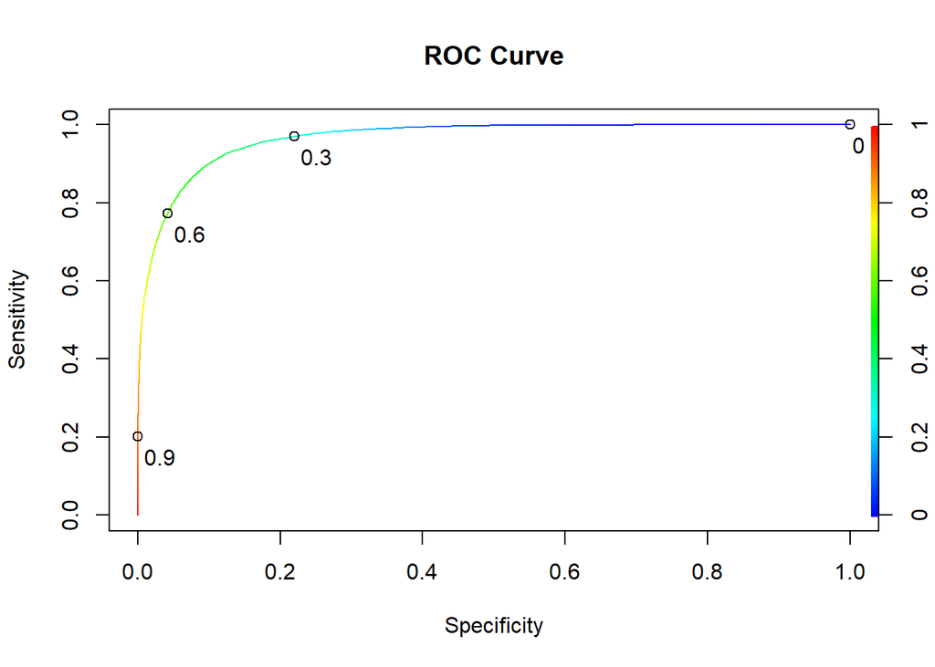

```r
xgb2_tr_ROC= predict(xgb2, train_x, type='prob')
xgb2pred_tr= prediction(xgb2_tr_ROC, train_y)
perf= performance(xgb2pred_tr,'tpr', 'fpr')
plot(perf, colorize=T,
       main='ROC Curve',
       ylab= 'Sensitivity',
       xlab= 'Specificity',
       print.cutoffs.at=seq(0,1,0.3),
       text.adj= c(-0.2,1.7))
```

```r
auc= as.numeric(performance(xgb2pred_tr, 'auc')@y.values)
auc=round(auc,3)
print(paste('AUC:', auc))
```

```
## [1] "AUC: 0.966"
```

#Prediction and evaluation on test set

```r
#predict using training set
pred_xgb2_ts <- predict(xgb2, test_x)
#transform them in a 0 1 variable
pred_xgb2_ts<- as.numeric(pred_xgb2_ts>0.5)
confusionMatrix(factor(pred_xgb2_ts),factor(test_y))
```

```
## Confusion Matrix and Statistics
##
##           Reference
## Prediction    0    1
##          0 8689 1805
##          1 1879 4328
##
##                Accuracy : 0.7794
##                  95% CI : (0.773, 0.7857)
##     No Information Rate : 0.6328
##     P-Value [Acc > NIR] : <2e-16
##
##                   Kappa : 0.5266
##
##  Mcnemar's Test P-Value : 0.2291
##
##             Sensitivity : 0.8222
##             Specificity : 0.7057
##          Pos Pred Value : 0.8280
##          Neg Pred Value : 0.6973
##              Prevalence : 0.6328
##          Detection Rate : 0.5203
##    Detection Prevalence : 0.6283
##       Balanced Accuracy : 0.7639
##
##        'Positive' Class : 0
##
```

#ROC plot and AUC

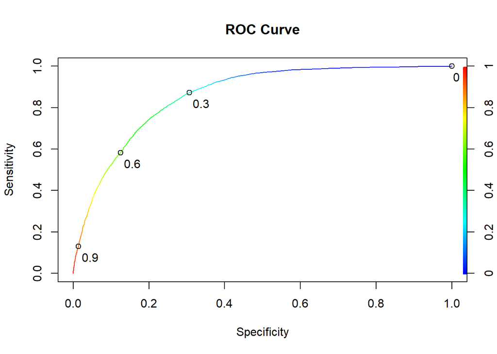

```r
xgb2_ts_ROC= predict(xgb2, test_x, type='prob')
xgb2pred_ts= prediction(xgb2_ts_ROC, test_y)
perf= performance(xgb2pred_ts,'tpr', 'fpr')
plot(perf, colorize=T,
       main='ROC Curve',
       ylab= 'Sensitivity',
       xlab= 'Specificity',
       print.cutoffs.at=seq(0,1,0.3),
       text.adj= c(-0.2,1.7))
```

```r
auc= as.numeric(performance(xgb2pred_ts, 'auc')@y.values)
auc=round(auc,3)
print(paste('AUC:', auc))
```

```
## [1] "AUC: 0.859"
```

#Hyperparameter Tuning through cross validation

```r
set.seed(100)
# set up all the pairwise combinations

xgb_grid = expand.grid(nrounds = c(500,1000),
                       max_depth=c(5,8,12),
                       eta= c(0.0001,0.001),
                       gamma=3,
                       colsample_bytree=0.5,
                       min_child_weight=5,
                       subsample=0.5)

#use cross validation
xgb_trcontrol = trainControl(method = "cv",
                             number = 5,
                             verboseIter = TRUE,
                             returnData = FALSE,
                             returnResamp = "all",
                             allowParallel = TRUE)

xgb_cv= train(x = train_x,
                  y = as.factor(train_y),
                  trControl = xgb_trcontrol,
                  tuneGrid = xgb_grid,
                  method = "xgbTree")
```

[output not shown]

```r
xgb_cv$finalModel
```

```
## ##### xgb.Booster
## raw: 21 Mb
## call:
##   xgboost::xgb.train(params = list(eta = param$eta, max_depth = param$max_depth,
##     gamma = param$gamma, colsample_bytree = param$colsample_bytree,
##     min_child_weight = param$min_child_weight, subsample = param$subsample),
##     data = x, nrounds = param$nrounds, objective = "binary:logistic")
## params (as set within xgb.train):
##   eta = "0.001", max_depth = "12", gamma = "3", colsample_bytree = "0.5", min_child_weight = "5", subsample = "0.5", objective = "binary:logistic", validate_parameters = "TRUE"
## xgb.attributes:
##   niter
## callbacks:
##   cb.print.evaluation(period = print_every_n)
## # of features: 20
## niter: 1000
## nfeatures : 20
## xNames : gender_F gender_M tartar_N tartar_Y age height.cm. weight.kg. waist.cm. systolic relaxation fasting.blood.sugar cholesterol triglyceride hdl ldl hemoglobin serum.creatinine ast alt gtp
## problemType : Classification
## tuneValue :
##     nrounds max_depth   eta gamma colsample_bytree min_child_weight subsample
## 12    1000        12 0.001     3              0.5                5       0.5
## obsLevels : 0 1
## param :
##  list()
```

#Model 3

```r
xgb3<- xgboost(data= train_x, label=train_y,
                    nround=1000, max_depth=12,
                    eta=0.001, gamma=3,
                    colsample_bytree=0.5,
                    min_child_weight=5,
                    subsample=0.5,
                    objective='binary:logistic')
```

# Prediction and evaluation on training set

```r
#predict using training set
xgb3pred_tr <- predict(xgb3, train_x)
#transform them in a 0 1 variable
xgb3pred_tr<- as.numeric(xgb3pred_tr>0.5)
confusionMatrix(factor(xgb3pred_tr),factor(train_y))
```

```
## Confusion Matrix and Statistics
##
##           Reference
## Prediction     0     1
##          0 20724  2454
##          1  3934 11855
##
##                Accuracy : 0.8361
##                  95% CI : (0.8324, 0.8397)
##     No Information Rate : 0.6328
##     P-Value [Acc > NIR] : < 2.2e-16
##
##                   Kappa : 0.6547
##
##  Mcnemar's Test P-Value : < 2.2e-16
##
##             Sensitivity : 0.8405
##             Specificity : 0.8285
##          Pos Pred Value : 0.8941
##          Neg Pred Value : 0.7508
##              Prevalence : 0.6328
##          Detection Rate : 0.5318
##    Detection Prevalence : 0.5948
##       Balanced Accuracy : 0.8345
##
##        'Positive' Class : 0
##
```

#ROC plot and AUC

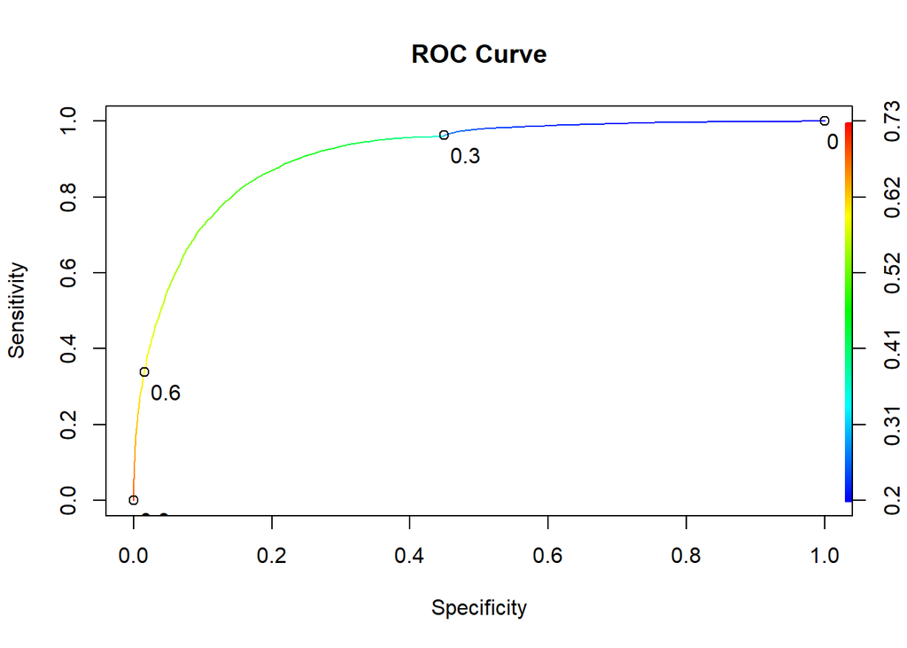

```r
xgb3pred_tr_ROC= predict(xgb3, train_x, type='prob')
xgb3pred_tr= prediction(xgb3pred_tr_ROC, train_y)
perf= performance(xgb3pred_tr,'tpr', 'fpr')
plot(perf, colorize=T,
       main='ROC Curve',
       ylab= 'Sensitivity',
       xlab= 'Specificity',
       print.cutoffs.at=seq(0,1,0.3),
       text.adj= c(-0.2,1.7))
```

```r
auc= as.numeric(performance(xgb3pred_tr, 'auc')@y.values)
auc=round(auc,3)
print(paste('AUC:', auc))
```

```
## [1] "AUC: 0.912"
```

#Prediction and evaluation on test set

```r
#predict using training set
xgb3pred_ts <- predict(xgb3, test_x)
#transform them in a 0 1 variable
xgb3pred_ts<- as.numeric(xgb3pred_ts>0.5)
confusionMatrix(factor(xgb3pred_ts),factor(test_y))
```

```
## Confusion Matrix and Statistics
##
##           Reference
## Prediction    0    1
##          0 8376 1597
##          1 2192 4536
##
##                Accuracy : 0.7731
##                  95% CI : (0.7667, 0.7795)
##     No Information Rate : 0.6328
##     P-Value [Acc > NIR] : < 2.2e-16
##
##                   Kappa : 0.5216
##
##  Mcnemar's Test P-Value : < 2.2e-16
##
##             Sensitivity : 0.7926
##             Specificity : 0.7396
##          Pos Pred Value : 0.8399
##          Neg Pred Value : 0.6742
##              Prevalence : 0.6328
##          Detection Rate : 0.5015
##    Detection Prevalence : 0.5971
##       Balanced Accuracy : 0.7661
##
##        'Positive' Class : 0
##
```

#ROC plot and AUC

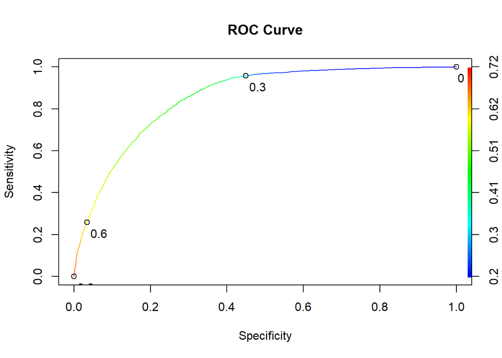

```r
xgb3pred_ts_ROC= predict(xgb3, test_x, type='prob')
xgb3pred_ts= prediction(xgb3pred_ts_ROC, test_y)
perf= performance(xgb3pred_ts,'tpr', 'fpr')
plot(perf, colorize=T,
       main='ROC Curve',
       ylab= 'Sensitivity',
       xlab= 'Specificity',
       print.cutoffs.at=seq(0,1,0.3),
       text.adj= c(-0.2,1.7))
```

```r
auc= as.numeric(performance(xgb3pred_ts, 'auc')@y.values)
auc=round(auc,3)
print(paste('AUC:', auc))
```

```
## [1] "AUC: 0.855"
```

#compare xgb models

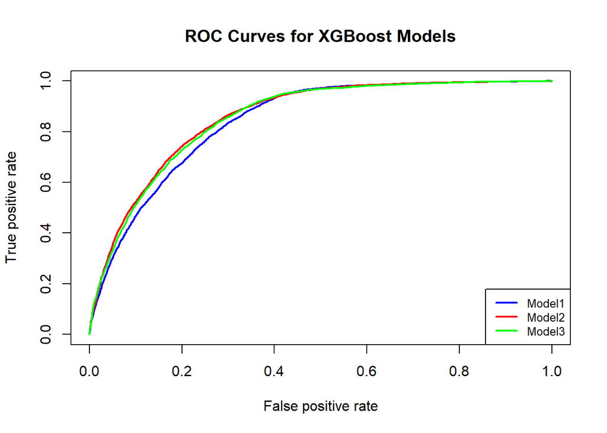

```r
xgb1_pred_prob= predict(xgb1, test_x, type='prob')
xgb1_pred= prediction(xgb1_pred_prob, test_y)
xgb1_perf= performance(xgb1_pred,'tpr', 'fpr')
plot(xgb1_perf, col='blue', lwd=2, main='ROC Curves for XGBoost Models' )

xgb2_pred_prob= predict(xgb2, test_x, type='prob')
xgb2_pred= prediction(xgb2_pred_prob, test_y)
xgb2_perf= performance(xgb2_pred,'tpr', 'fpr')
plot(xgb2_perf, col='red', lwd=2, add=TRUE )

xgb3_pred_prob= predict(xgb3, test_x, type='prob')
xgb3_pred= prediction(xgb3_pred_prob, test_y)
xgb3_perf= performance(xgb3_pred,'tpr', 'fpr')
plot(xgb3_perf, col='green', lwd=2, add=TRUE )

legend('bottomright', legend=c('Model1', 'Model2', 'Model3'), col=c('blue', 'red', 'green'), lwd=2, cex=0.8)
```

#Combine the best model of each method

[figure not shown]

```r
rf_pred_prob<- predict(rf3, type='prob', test[, -19])[,2]
rf_pred<- prediction(rf_pred_prob,test$smoking)
rf_perf= performance(rf_pred, 'tpr','fpr')
plot(rf_perf, col='red', lwd=4, main='ROC Curves for Decision Tree, Random Forest and XGBoost')

dt_pred_prob<- predict(dt3, type='prob',test[, -19])[,2]
dt_pred= prediction(dt_pred_prob, test$smoking)
dt_perf= performance(dt_pred, 'tpr','fpr')
plot(dt_perf, col='blue', lwd=2, add=TRUE)

xgb_pred_prob= predict(xgb2, test_x, type='prob')
xgb_pred= prediction(xgb_pred_prob, test_y)
xgb_perf= performance(xgb_pred,'tpr', 'fpr')
plot(rf_perf, col='green', lwd=2, add=TRUE)

legend('bottomright', legend=c('Decision Tree', 'Random Forest', 'XGBoost'), col=c('blue', 'red', 'green'), lwd=2, cex=0.8)
```